# Week 8 practice: Linear modeling and `broom`

To practice the new tests we’ve learned, we’ll use the built-in `mtcars` dataset.

## Test Practice

### correlation

What is the correlation between horsepower and weight? Is it significant?

```r
mtcars %$% cor.test(hp, wt) %>% tidy()
```

```
## # A tibble: 1 x 8
##   estimate statistic p.value parameter conf.low conf.high method
##      <dbl>     <dbl>   <dbl>     <int>    <dbl>     <dbl> <chr>
## 1    0.659      4.80 4.15e-5        30    0.403     0.819 Pears…
## # ... with 1 more variable: alternative <chr>
```

### linear model

#### Plot

Plot a scatterplot of the rear axle ratio vs. fuel displacement. Does the relationship look linear?

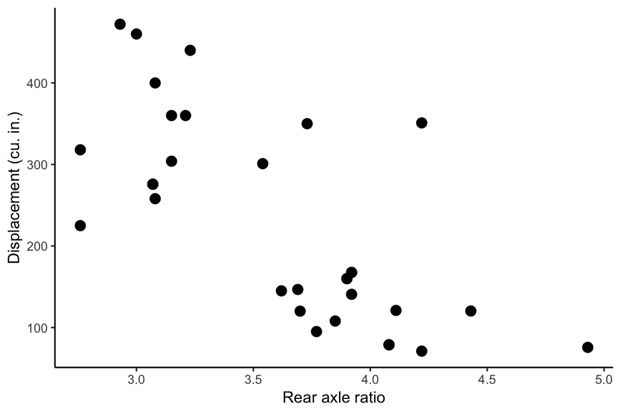

```r
ggplot(mtcars, aes(x = drat, y = disp)) +
  geom_point(size = 3) +
  labs(x = 'Rear axle ratio', y = 'Displacement (cu. in.)') +
  theme_classic()
```

#### Test

Since the relationship looks approximately linear, test it with `lm()`

```r
lm(disp ~ drat, data = mtcars) %>% tidy()
```

```
## # A tibble: 2 x 5
##   term        estimate std.error statistic      p.value
##   <chr>          <dbl>     <dbl>     <dbl>        <dbl>
## 1 (Intercept)     823.     108.       7.60 0.0000000179
## 2 drat           -165.      29.8     -5.53 0.00000528
```

### ANOVA

Do an ANOVA of quarter mile time over the number of cylinders in the the engine.

```r
aov(qsec ~ cyl, data = mtcars) %>% tidy()
```

```
## # A tibble: 2 x 6
##   term         df sumsq meansq statistic   p.value
##   <chr>     <dbl> <dbl>  <dbl>     <dbl>     <dbl>
## 1 cyl           1  34.6  34.6       16.1  0.000366
## 2 Residuals    30  64.4   2.15      NA   NA
```

Now take the same ANOVA from the chunk above and add a post-hoc Tukey test to it.

```r
aov(qsec ~ as.factor(cyl), data = mtcars) %>% TukeyHSD() %>% tidy()
```

```
## # A tibble: 3 x 6
##   term           comparison estimate conf.low conf.high adj.p.value
##   <chr>          <chr>         <dbl>    <dbl>     <dbl>       <dbl>
## 1 as.factor(cyl) 6-4           -1.16    -2.94     0.619     0.257
## 2 as.factor(cyl) 8-4           -2.37    -3.85    -0.883     0.00133
## 3 as.factor(cyl) 8-6           -1.20    -2.91     0.498     0.205
```

### broom

Pick one of the three tests you did above and practice tidying it up with the three `broom` functions!

#### `tidy()`

Add `tidy()` onto end of your test.

```r
aov(qsec ~ cyl, data = mtcars) %>% tidy()
```

```
## # A tibble: 2 x 6
##   term         df sumsq meansq statistic   p.value
##   <chr>     <dbl> <dbl>  <dbl>     <dbl>     <dbl>
## 1 cyl           1  34.6  34.6       16.1  0.000366
## 2 Residuals    30  64.4   2.15      NA   NA
```

#### `glance()`

Add `glance()` onto the end of your test to look at the model parameters.

```r
aov(cyl ~ qsec, data = mtcars) %>% glance()
```

```
## # A tibble: 1 x 11
##   r.squared adj.r.squared sigma statistic p.value    df logLik   AIC   BIC
## *     <dbl>         <dbl> <dbl>     <dbl>   <dbl> <int>  <dbl> <dbl> <dbl>
## 1     0.350         0.328  1.46      16.1 3.66e-4     2  -56.6  119.  124.
## # ... with 2 more variables: deviance <dbl>, df.residual <int>
```

#### `augment()`

Add the results of the test back to mtcars using `augment()`

```r
aov(cyl ~ qsec, data = mtcars) %>% augment(mtcars)
```

```
## # A tibble: 32 x 19
##    .rownames   mpg   cyl  disp    hp  drat    wt  qsec    vs    am  gear
##  * <chr>     <dbl> <dbl> <dbl> <dbl> <dbl> <dbl> <dbl> <dbl> <dbl> <dbl>
##  1 Mazda RX4  21       6  160    110  3.9   2.62  16.5     0     1     4
##  2 Mazda RX…  21       6  160    110  3.9   2.88  17.0     0     1     4
##  3 Datsun 7…  22.8     4  108     93  3.85  2.32  18.6     1     1     4
##  4 Hornet 4…  21.4     6  258    110  3.08  3.22  19.4     1     0     3
##  5 Hornet S…  18.7     8  360    175  3.15  3.44  17.0     0     0     3
##  6 Valiant    18.1     6  225    105  2.76  3.46  20.2     1     0     3
##  7 Duster 3…  14.3     8  360    245  3.21  3.57  15.8     0     0     3
##  8 Merc 240D  24.4     4  147.    62  3.69  3.19  20       1     0     4
##  9 Merc 230   22.8     4  141.    95  3.92  3.15  22.9     1     0     4
## 10 Merc 280   19.2     6  168.   123  3.92  3.44  18.3     1     0     4
## # ... with 22 more rows, and 8 more variables: carb <dbl>, .fitted <dbl>,
## #   .se.fit <dbl>, .resid <dbl>, .hat <dbl>, .sigma <dbl>, .cooksd <dbl>,
## #   .std.resid <dbl>
```

Use the augmented table from the chunk above to plot something.

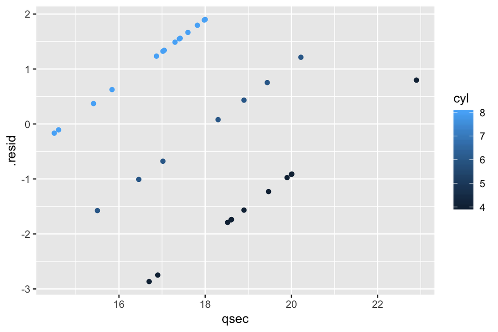

```r
aov(cyl ~ qsec, data = mtcars) %>% augment(mtcars) %>%
  ggplot(aes(x = qsec, y = .resid, color = cyl)) +
  geom_point()
```

## Come Up with Your Own Questions

Use the tests talked about this week, `cor()`, `cor.test()`, `lm()`, `aov()`, and/or `TukeyHSD()` to ask two more questions about the `mtcars` dataset.

### Question 1

#### Plot

Look at mtcars again. What’s another question you could ask about it? Plot the variable(s) you’re interested in below

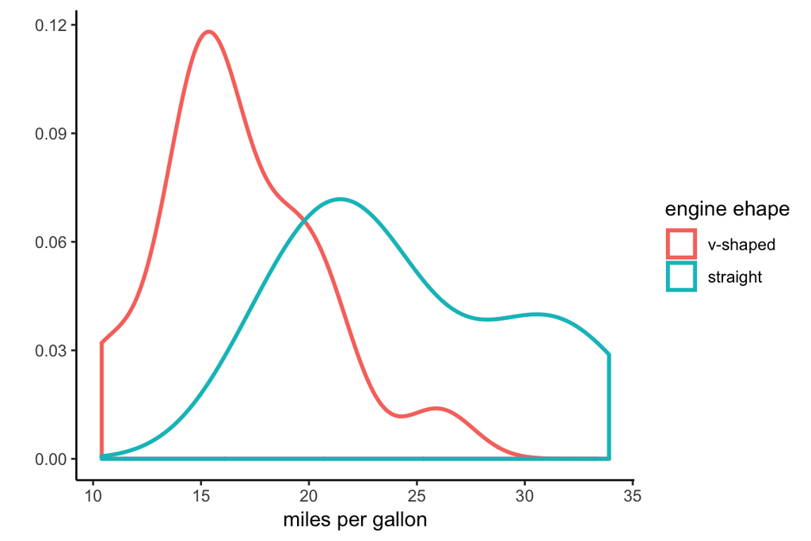

```r
ggplot(mtcars, aes(x = mpg, color = as.factor(vs))) +
  geom_density(size = 1) +
  labs(x = 'miles per gallon', y = '') +
  scale_color_discrete(name = 'engine ehape', labels = c('v-shaped', 'straight')) +
  theme_classic()
```

#### Ask a Question

Based on the variables you just plotted, what’s your question?

**Does engine shape affect the number of miles per gallon a car gets?**

#### Test

Pick one of the tests to answer your question and run it in the chunk below.

```r
aov(mpg ~ as.factor(vs), data = mtcars) %>% tidy()
```

```
## # A tibble: 2 x 6
##   term             df sumsq meansq statistic    p.value
##   <chr>         <dbl> <dbl>  <dbl>     <dbl>      <dbl>
## 1 as.factor(vs)     1  497.  497.       23.7  0.0000342
## 2 Residuals        30  630.   21.0      NA   NA
```

#### Answer the Question

What do you conclude from your test?

**With a p-value of 0.0000342, it’s unlikely that the difference in mpg between the different engine types is due to chance.**

### Question 2

### Plot

Look at mtcars again. What’s another question you could ask about it? Plot the variable(s) you’re interested in below

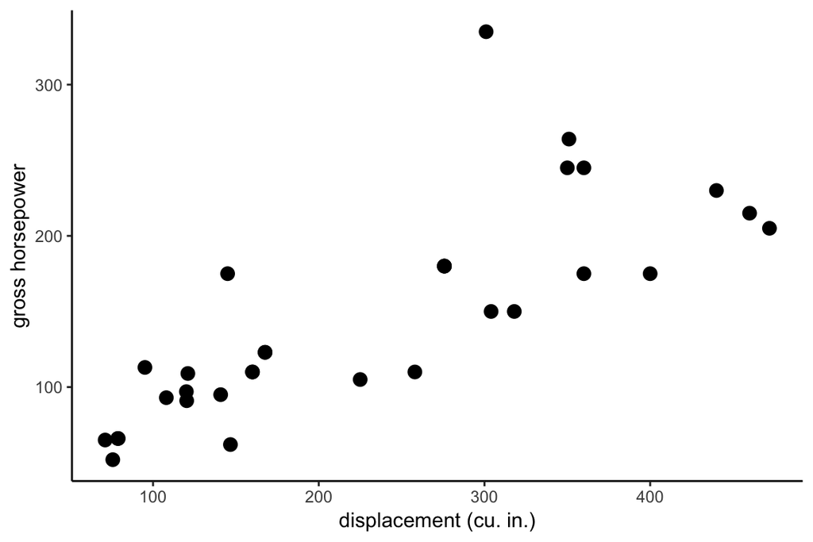

```r
ggplot(mtcars, aes(x = disp, y = hp)) +
  geom_point(size = 3) +
  labs(x = 'displacement (cu. in.)', y = 'gross horsepower') +
  theme_classic()
```

#### Ask a Question

Based on the variables you just plotted, what’s your question?

**Can displacement predict horsepower?**

#### Test

Pick one of the tests to answer your question and run it in the chunk below.

```r
lm(hp ~ disp, data = mtcars) %>% tidy()
```

```
## # A tibble: 2 x 5
##   term        estimate std.error statistic      p.value
##   <chr>          <dbl>     <dbl>     <dbl>        <dbl>
## 1 (Intercept)   45.7     16.1         2.84 0.00811
## 2 disp           0.438    0.0618      7.08 0.0000000714
```

#### Answer the Question

What do you conclude from your test?

**With a p-value of 0.00811 for the y-intercept and a p-value of 7.14e-8 for the slope, displacement can make a good prediction of the car’s horsepower.**